◀ Back to Course Hub PAF 512 | Advanced Regression

# Difference-in-Differences | Codethrough

PAF 512 - Advanced Regression

# What will we cover?

#### 1. Introduction to Difference-in-Differences

- Understanding the DID Research Design
- Key Assumptions and Requirements

#### 2. Build and Run the DID Model

- Load and Explore the Dataset
- Create DID Variables
- Estimate the Model

#### 3. Interpret Model Coefficients

- Understanding Each Beta Coefficient
- Calculating Group Means from Coefficients

#### 4. Visualize the DID Design

- Plot Group Means Over Time
- Illustrate the Treatment Effect

#### 5. Calculate the Counterfactual

- Construct the Counterfactual Scenario
- Quantify Program Impact

#### 6. Comparing DID and ITS Approaches

- When to Use Each Method
- Running Both Models on the Same Data
- Understanding the Differences

# Introduction

## What is Difference-in-Differences?

Difference-in-Differences (DID) is a quasi-experimental research design used to estimate causal effects of interventions or policy changes. The approach compares the change in outcomes over time between a group that received treatment and a group that did not.

### The Core Logic

The DID estimator captures:

1. **The difference** in the treatment group before and after the intervention
2. **Minus the difference** in the control group over the same period

This “difference of differences” isolates the treatment effect by removing:

- Pre-existing differences between groups
- Common time trends affecting both groups

### The Mathematical Formula

$$(Treatment_{post} - Treatment_{pre}) -
(Control_{post} - Control_{pre}) = DID$$

### The Statistical Model

We estimate the following regression:

$$Y = \beta_0 + \beta_1 \cdot Group +
\beta_2 \cdot Post + \beta_3 \cdot (Group \times Post) +
\epsilon$$

Where:

- **Y** is the outcome variable
- **Group** is a dummy variable (1 = treatment group, 0 = control group)
- **Post** is a dummy variable (1 = post-treatment period, 0 = pre-treatment period)
- **Group × Post** is the interaction term that captures the DID effect

### Key Assumptions

The success of a DID analysis rests on two critical assumptions:

1. **Parallel Trends Assumption:** In the absence of treatment, the treatment and control groups would have followed similar trends over time. This is the most important and often most challenging assumption to satisfy.
2. **No Spillover Effects:** The treatment of one group does not affect the outcomes of the control group.

# Data

We will use the **injury** dataset from the `wooldridge` package, which contains data on workplace injuries and workers’ compensation benefits in Kentucky and Michigan.

## Policy Context

In 1980, Kentucky increased workers’ compensation benefits for workplace injuries, while Michigan did not change its benefit structure. This provides a natural experiment to study whether higher benefits lead to longer injury durations (potentially due to moral hazard (i.e., workers may stay out longer when benefits are more generous).

- **Research Question:** Did increasing workers’ compensation benefits in Kentucky lead to longer injury durations?
- **Hypothesis:** Higher workers’ compensation benefits will increase the duration of workplace injuries.

## Dataset Details

- **Treatment Group:** Kentucky (increased benefits in 1980)
- **Control Group:** Michigan (no change in benefits)
- **Time Periods:** Before 1980 (pre-treatment) and 1980 onwards (post-treatment)
- **Outcome Variable:** Duration of workplace injuries (in weeks)

## Setup and Data Loading

```r
# Install/Load Packages
# install.packages("wooldridge")
# install.packages("stargazer")
# install.packages("dplyr")
library(wooldridge)   # Contains the injury dataset
library(stargazer)    # Clean regression tables
library(dplyr)        # Data manipulation
```

## Load and Inspect Data

```r
# Load the injury dataset
data(injury)

# Display structure of the dataset
str(injury)
```

```
## 'data.frame':    7150 obs. of  30 variables:
##  $ durat   : num  1 1 84 4 1 1 7 2 175 60 ...
##  $ afchnge : int  1 1 1 1 1 1 1 1 1 1 ...
##  $ highearn: int  1 1 1 1 1 1 1 1 1 1 ...
##  $ male    : int  1 1 1 1 1 1 1 1 1 1 ...
##  $ married : int  0 1 1 1 1 1 1 1 1 1 ...
##  $ hosp    : int  1 0 1 1 0 0 0 1 1 1 ...
##  $ indust  : int  3 3 3 3 3 3 3 3 3 3 ...
##  $ injtype : int  1 1 1 1 1 1 1 1 1 1 ...
##  $ age     : int  26 31 37 31 23 34 35 45 41 33 ...
##  $ prewage : num  405 644 398 528 529 ...
##  $ totmed  : num  1188 361 8964 1100 373 ...
##  $ injdes  : int  1010 1404 1032 1940 1940 1425 1110 1207 1425 1010 ...
##  $ benefit : num  247 247 247 247 212 ...
##  $ ky      : int  1 1 1 1 1 1 1 1 1 1 ...
```

[output cut: 17 more lines]

## Key Variables

Let’s identify the key variables we’ll use:

```r
# Summary statistics for key variables
summary(injury[, c("durat", "afchnge","highearn", "ky")])
```

```
##      durat            afchnge          highearn            ky
##  Min.   :  0.250   Min.   :0.0000   Min.   :0.0000   Min.   :0.0000
##  1st Qu.:  2.000   1st Qu.:0.0000   1st Qu.:0.0000   1st Qu.:1.0000
##  Median :  4.000   Median :0.0000   Median :0.0000   Median :1.0000
##  Mean   :  9.922   Mean   :0.4733   Mean   :0.3989   Mean   :0.7869
##  3rd Qu.:  8.000   3rd Qu.:1.0000   3rd Qu.:1.0000   3rd Qu.:1.0000
##  Max.   :182.000   Max.   :1.0000   Max.   :1.0000   Max.   :1.0000
```

**Variable Descriptions:**

| Variable | Description |
| --- | --- |
| `durat` | Duration of injury (in weeks) |
| `ky` | State indicator (1 = Kentucky, 0 = Michigan) - our Group variable |
| `afchnge` | Time period indicator (1 = after policy change, 0 = before) - our Post variable |
| `highearn` | High earner indicator (1 = above median earnings) |

# Difference-in-Difference

## Build Model

### Create Variables

While the injury dataset already contains the necessary dummy variables, let’s create them explicitly to understand the DID structure:

```r
# Rename `ky` for clarity (treatment group flag)
injury$Group <- injury$ky

# Rename `afchng` for clarity (Post invervention flag)
injury$Post <- injury$afchnge

# Create the interaction term (Group × Post)
injury$Group_Post <- injury$Group * injury$Post

rbind(
  head(injury[,c("Group", "Post", "Group_Post")], 5),
  tail(injury[,c("Group", "Post", "Group_Post")], 5)
  )
```

```
##      Group Post Group_Post
## 1        1    1          1
## 2        1    1          1
## 3        1    1          1
## 4        1    1          1
## 5        1    1          1
## 7146     0    0          0
## 7147     0    0          0
## 7148     0    0          0
## 7149     0    0          0
## 7150     0    0          0
```

```r
# Verify the variables and check counts
injury %>%
  group_by(Group, Post) %>%
  summarise(n = n(), .groups = "drop") %>%
  mutate(
    Group_Label = ifelse(Group == 1, "Kentucky", "Michigan"),
    Period = ifelse(Post == 1, "Post-1980", "Pre-1980")
  ) %>%
  select(Group_Label, Period, n)
```

```
## # A tibble: 4 × 3
##   Group_Label Period        n
##   <chr>       <chr>     <int>
## 1 Michigan    Pre-1980    828
## 2 Michigan    Post-1980   696
## 3 Kentucky    Pre-1980   2938
## 4 Kentucky    Post-1980  2688
```

### Explore Group Means

Before running the regression, let’s calculate the means for each group in each time period. This will help us understand what each coefficient represents.

```r
# Calculate means for all four combinations
group_means <- injury %>%
  group_by(Group, Post) %>%
  summarise(
    Mean_Duration = mean(durat, na.rm = TRUE),
    N = n(),
    .groups = "drop"
  ) %>%
  mutate(
    Group_Label = ifelse(Group == 1, "Kentucky (Treatment)", "Michigan (Control)"),
    Period = ifelse(Post == 1, "Post (After 1980)", "Pre (Before 1980)")
  )

# Display the means
group_means %>%
  select(Group_Label, Period, Mean_Duration, N)
```

```
## # A tibble: 4 × 4
##   Group_Label          Period            Mean_Duration     N
##   <chr>                <chr>                     <dbl> <int>
## 1 Michigan (Control)   Pre (Before 1980)         12.1    828
## 2 Michigan (Control)   Post (After 1980)         15.5    696
## 3 Kentucky (Treatment) Pre (Before 1980)          8.33  2938
## 4 Kentucky (Treatment) Post (After 1980)          9.57  2688
```

### Manual DID Calculation

Let’s calculate the DID estimator manually using the group means to understand the logic:

```r
# Extract the four means
C_pre <- group_means %>% filter(Group == 0, Post == 0) %>% pull(Mean_Duration)
C_post <- group_means %>% filter(Group == 0, Post == 1) %>% pull(Mean_Duration)
T_pre <- group_means %>% filter(Group == 1, Post == 0) %>% pull(Mean_Duration)
T_post <- group_means %>% filter(Group == 1, Post == 1) %>% pull(Mean_Duration)

# Calculate the differences
diff_treatment <- T_post - T_pre
diff_control <- C_post - C_pre
did_estimate <- diff_treatment - diff_control

# Display results
cat("Control Group (Michigan):\n")
```

```
## Control Group (Michigan):
```

```r
cat("  Pre-treatment mean:", round(C_pre, 2), "weeks\n")
```

```
##   Pre-treatment mean: 12.06 weeks
```

```r
cat("  Post-treatment mean:", round(C_post, 2), "weeks\n")
```

```
##   Post-treatment mean: 15.47 weeks
```

```r
cat("  Change:", round(diff_control, 2), "weeks\n\n")
```

```
##   Change: 3.41 weeks
```

```r
cat("Treatment Group (Kentucky):\n")
```

```
## Treatment Group (Kentucky):
```

```r
cat("  Pre-treatment mean:", round(T_pre, 2), "weeks\n")
```

```
##   Pre-treatment mean: 8.33 weeks
```

```r
cat("  Post-treatment mean:", round(T_post, 2), "weeks\n")
```

```
##   Post-treatment mean: 9.57 weeks
```

```r
cat("  Change:", round(diff_treatment, 2), "weeks\n\n")
```

```
##   Change: 1.24 weeks
```

```r
cat("Difference-in-Differences:\n")
```

```
## Difference-in-Differences:
```

```r
cat("  (", round(diff_treatment, 2), ") - (", round(diff_control, 2), ") =", round(did_estimate, 2), "weeks\n")
```

```
##   ( 1.24 ) - ( 3.41 ) = -2.17 weeks
```

### Run the Model

Now let’s estimate the model using regression:

```r
# Run the DID regression
DID_model <- lm(durat ~ Group + Post + Group_Post, data = injury)

# Display results
stargazer(DID_model,
          type = "html",
          #type = "text",
          dep.var.labels = "Injury Duration (weeks)",
          column.labels = "DID Model",
          covariate.labels = c("Control Group (Pre): (β0)",
                               "Delta Treatment Group (Pre) (β1)",
                               "Delta Control Group (Post) (β2)",
                               "DID Estimator (β3)"),
          omit.stat = "all",
          digits = 2,
          intercept.bottom = FALSE)
```

|  | *Dependent variable:* |
| --- | --- |
|  | Injury Duration (weeks) |
|  | DID Model |
| Control Group (Pre): (β0) | 12.06*** |
|  | (0.85) |
| Delta Treatment Group (Pre) (β1) | -3.73*** |
|  | (0.96) |
| Delta Control Group (Post) (β2) | 3.41*** |
|  | (1.26) |
| DID Estimator (β3) | -2.17 |
|  | (1.41) |
| *Note:* | p<0.1; p<0.05; p<0.01 |

## Interpret Model Coefficient

**$\beta_0$**: Control Group, Pre-Intervention Mean

- The average number of weeks spent on workers compensation benefits in Michigan, during the pre-intervention period, was $12.06$. This is statistically significant as it is different from $0$.

**$\beta_1$**: Pre-Intervention Delta between Treatment and Control

- The treatment group (Kentucky) had claimants spending, on average, $3.73$ **fewer weeks** on workers compensation benefits compared to the control group (Michigan). This is statistically significant, suggesting the groups were different prior to intervention.

**$\beta_2$**: Pre-to-Post Period Delta within Control Group (`Secular Trend`)

- From the pre-to-post period, the number of weeks Michigan’s workers stayed on workers compensation grew by $3.41$. This is statistically significant.

**$\beta_3$**: Treatment effect (`Difference-In-Difference Estimator`)

**Instructor’s Note:**

**Important:** Groups do NOT need to be identical in the pre-treatment period for valid DID inference. They only need to have **parallel trends**. The DID design accounts for baseline differences through the $\beta_1$ coefficient.

## Summarize Interpretations

```r
# Extract coefficients
b0 <- coef(DID_model)[1]  # Constant
b1 <- coef(DID_model)[2]  # Group
b2 <- coef(DID_model)[3]  # Post
b3 <- coef(DID_model)[4]  # Group x Post

# Create a comprehensive summary table
coef_summary <- data.frame(
  Coefficient = c("B0",
  "B1",
  "B2",
  "B3"),
  Value = round(c(b0, b1, b2, b3), 2),
  Interpretation = c(
    "Control group mean before treatment",
    "Difference between groups before treatment",
    "Change in control group over time (secular trend)",
    "Additional change in treatment group (treatment effect)"),
  Hypothesis = c(
    "Is control pre-treatment mean != 0?",
    "Did groups differ before treatment?",
    "Did control group change over time?",
    "Did treatment have an effect?")
  )

coef_summary
```

[output not shown]

## Group Means from Coefficients

We know how to interpret the coefficients and therefore tell the differences between groups, but how do we calculate the actual values from our coefficients?

### The Four Group Means

```r
# Calculate each group mean from coefficients
control_pre <- b0
control_post <- b0 + b2

treatment_pre <- b0 + b1
treatment_post <- b0 + b1 + b2 + b3

# Create comparison table
means_table <- data.frame(
  Group = c("Control (Michigan)", "Control (Michigan)",
            "Treatment (Kentucky)", "Treatment (Kentucky)"),
  Period = c("Pre-1980", "Post-1980", "Pre-1980", "Post-1980"),
  Formula = c(
  "$\\beta_0$",
  "$\\beta_0 + \\beta_2$",
  "$\\beta_0 + \\beta_1$",
  "$\\beta_0 + \\beta_1 + \\beta_2 + \\beta_3$"),
  Calculated = round(c(control_pre, control_post, treatment_pre, treatment_post), 2),
  Actual = round(c(C_pre, C_post, T_pre, T_post), 2)
)

means_table
```

```
##                  Group    Period                                     Formula
## 1   Control (Michigan)  Pre-1980                                  $\\beta_0$
## 2   Control (Michigan) Post-1980                       $\\beta_0 + \\beta_2$
## 3 Treatment (Kentucky)  Pre-1980                       $\\beta_0 + \\beta_1$
## 4 Treatment (Kentucky) Post-1980 $\\beta_0 + \\beta_1 + \\beta_2 + \\beta_3$
##   Calculated Actual
## 1      12.06  12.06
## 2      15.47  15.47
## 3       8.33   8.33
## 4       9.57   9.57
```

## Visualize the DID Design

Visualization is crucial for understanding and communicating DID results. Let’s create a graph that clearly shows the treatment effect.

### Create the DID Plot

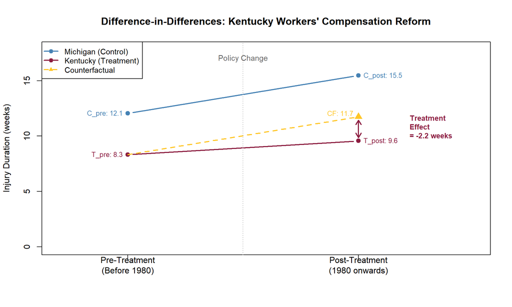

```r
# Calculate counterfactual (what would have happened to treatment group without treatment)
counterfactual <- T_pre + (C_post - C_pre)

# Create the plot
plot(c(1, 2), c(C_pre, C_post), type = "b", col = "steelblue", pch = 19, lwd = 2,
     ylim = c(0, max(c(C_post, T_post, counterfactual)) * 1.15),
     xlim = c(0.7, 2.5),
     xlab = "", ylab = "Injury Duration (weeks)",
     main = "Difference-in-Differences: Kentucky Workers' Compensation Reform",
     xaxt = "n")

# Add custom x-axis
axis(1, at = c(1, 2), labels = c("Pre-Treatment\n(Before 1980)", "Post-Treatment\n(1980 onwards)"))

# Add treatment group line (actual outcomes)
lines(c(1, 2), c(T_pre, T_post), col = "#8C1D40", lwd = 2, type = "b", pch = 19)

# Add counterfactual line (dashed)
lines(c(1, 2), c(T_pre, counterfactual), col = "#FFC627", lwd = 2, lty = 2)
points(2, counterfactual, col = "#FFC627", pch = 17, cex = 1.5)

# Add vertical line at intervention
abline(v = 1.5, col = "gray", lty = 3, lwd = 1)
text(1.5, max(c(C_post, T_post)) * 1.1, "Policy Change", col = "gray40", cex = 0.9)

# Add labels for means
text(1, C_pre, paste0("C_pre: ", round(C_pre, 1)), pos = 2, cex = 0.8, col = "steelblue")
text(2, C_post, paste0("C_post: ", round(C_post, 1)), pos = 4, cex = 0.8, col = "steelblue")
text(1, T_pre, paste0("T_pre: ", round(T_pre, 1)), pos = 2, cex = 0.8, col = "#8C1D40")
text(2, T_post, paste0("T_post: ", round(T_post, 1)), pos = 4, cex = 0.8, col = "#8C1D40")
text(2, (counterfactual + .3), paste0("CF: ", round(counterfactual, 1)), pos = 2, cex = 0.8, col = "#FFC627")

# Add arrow showing treatment effect
arrows(2, counterfactual-.3, 2, T_post+.3,
       code = 3, length = 0.1, col = "#8C1D40", lwd = 2)
text(2.2, (counterfactual + T_post) / 2,
     paste0("Treatment\nEffect\n= ", round(T_post - counterfactual, 1), " weeks"),
     pos = 4, col = "#8C1D40", cex = 0.85, font = 2)

# Add legend
legend("topleft",
       legend = c("Michigan (Control)", "Kentucky (Treatment)", "Counterfactual"),
       col = c("steelblue", "#8C1D40", "#FFC627"),
       lty = c(1, 1, 2),
       pch = c(19, 19, 17),
       lwd = 2,
       cex = 0.9,
       bg = "white")
```

### Interpreting the Visualization

The graph above illustrates the core logic of difference-in-differences:

1. **Control Group - Michigan:** Shows the change in the number of weeks claimants stayed on workers compensation benefits when no policy change occurs. This represents the *secular trend*.
2. **Treatment Group - Kentucky:** Shows the change in the number of weeks claimants stayed on workers pre-and-post the increase in benefit amounts.
3. **Counterfactual:** Shows what *would have happened* to Kentucky if the policy had not changed, assuming Kentucky would have followed the same trend as Michigan.
4. **Treatment Effect:** The vertical distance between the actual outcome and the counterfactual represents the treatment effect - how much the policy changed the number of weeks claimants stayed on workers compensation benefits.

## Counterfactual

### The Counterfactual Formula

In a DID model, the counterfactual for the treatment group is:

$$Counterfactual = \beta_0 + \beta_1 +
\beta_2$$

This formula adds together:

- $\beta_0$: The control group’s pre-treatment mean (baseline)
- $\beta_1$: The pre-treatment difference between groups (Kentucky’s baseline difference)
- $\beta_2$: The time trend from the control group (what happened to everyone)

**Simply remove the DiD Estimator!**

### Calculate the Counterfactual

```r
# Calculate counterfactual using coefficients
counterfactual_calc <- b0 + b1 + b2

cat("Counterfactual Calculation:\n\n")
```

Counterfactual Calculation:

```r
cat("β0 (Control pre-mean): ", round(b0, 2), "\n")
```

β0 (Control pre-mean): 12.06

```r
cat("β1 (Group difference): ", round(b1, 2), "\n")
```

β1 (Group difference): -3.73

```r
cat("β2 (Time trend):       ", round(b2, 2), "\n")
```

β2 (Time trend): 3.41

```r
cat("\n")
```

```r
cat("**Counterfactual:** ", round(counterfactual_calc, 2), " weeks\n")
```

**Counterfactual:** 11.74 weeks

### Compare Values

```r
# Actual outcome in treatment group post-intervention
actual_outcome <- b0 + b1 + b2 + b3

# Treatment effect is the difference
treatment_effect <- actual_outcome - counterfactual_calc

cat("\nComparison:\n")
```

```
##
## Comparison:
```

```r
cat("  Counterfactual (expected without policy):", round(counterfactual_calc, 2), "weeks\n")
```

```
##   Counterfactual (expected without policy): 11.74 weeks
```

```r
cat("  Actual Outcome (observed with policy):   ", round(actual_outcome, 2), "weeks\n")
```

```
##   Actual Outcome (observed with policy):    9.57 weeks
```

```r
cat("  ─────────────────────────────────────────────\n")
cat("  Treatment Effect (β3):                   ", round(treatment_effect, 2), "weeks\n")
```

```
##   Treatment Effect (β3):                    -2.17 weeks
```

### Interpretation Summary

```r
# Create interpretation table
interpretation <- data.frame(
  Scenario = c("Counterfactual", "Actual Outcome", "Treatment Effect (β3)"),
  Value = paste0(round(c(counterfactual_calc, actual_outcome, treatment_effect), 2), " weeks"),
  Meaning = c(
    "Expected KY injury duration if policy unchanged",
    "Observed KY injury duration after policy change",
    "Additional weeks due to increased benefits"
  )
)

interpretation
```

```
##                Scenario       Value
## 1        Counterfactual 11.74 weeks
## 2        Actual Outcome  9.57 weeks
## 3 Treatment Effect (β3) -2.17 weeks
##                                           Meaning
## 1 Expected KY injury duration if policy unchanged
## 2 Observed KY injury duration after policy change
## 3      Additional weeks due to increased benefits
```

**Bottom Line:** The counterfactual tells us that if Kentucky had *not* increased workers’ compensation benefits, we would have expected average number of weeks claimants stayed on workers compensation benefits to be approximately **11.74 weeks** in the post-treatment period. Instead, the actual duration was **9.57 weeks** - about **2.17 weeks fewer** than expected. This difference, although not significant, would have been attributed to the policy change.

The parallel trends assumption is critical for difference-in-differences analysis. Without treatment, the treatment and control groups would have followed the same trend over time (i.e., parallel slopes).

### Why This Matters

If the parallel trends assumption is violated, the DID estimator will be biased. For example:

- If Kentucky’s average weeks on benefits were already increasing faster than Michigan’s prior to the policy change, we might mistakenly attribute this pre-existing difference in trends to the policy.
- Alternatively, if Kentucky was trending downward relative to Michigan, we might overestimate the policy’s true effect.

## Adding Control Variables

While our basic DID model provides the core treatment effect estimate, we can improve our model’s precision and account for additional variation by including control variables.

### Why Add Controls?

Control variables can:

1. **Reduce residual variance** — More precise estimates (smaller standard errors)
2. **Account for composition differences** — If the mix of workers differs between groups/periods
3. **Test for heterogeneous effects** — Did the policy affect different subgroups differently?

### Model with Controls

Let’s add the `highearn` variable to see if results are robust to controlling for earnings:

```r
# Run DID with controls
DID_controls <- lm(durat ~ Group + Post + Group_Post + highearn, data = injury)

# Compare models side by side
stargazer(DID_model, DID_controls,
          type = "html",
          #type = "text",
          dep.var.labels = "Injury Duration (weeks)",
          column.labels = c("Basic DID", "DID with Controls"),
          covariate.labels = c("Constant (β0)",
                               "Group: Kentucky (β1)",
                               "Post: After 1980 (β2)",
                               "DID Estimator (β3)",
                               "High Earner"),
          omit.stat = c("f", "ser"),
          digits = 2,
          intercept.bottom = FALSE)
```

|  | *Dependent variable:* |  |
| --- | --- | --- |
|  | Injury Duration (weeks) |  |
|  | Basic DID | DID with Controls |
|  | (1) | (2) |
| Constant (β0) | 12.06*** | 10.55*** |
|  | (0.85) | (0.86) |
| Group: Kentucky (β1) | -3.73*** | -4.42*** |
|  | (0.96) | (0.96) |
| Post: After 1980 (β2) | 3.41*** | 3.27*** |
|  | (1.26) | (1.25) |
| DID Estimator (β3) | -2.17 | -2.10 |
|  | (1.41) | (1.41) |
| High Earner |  | 5.24*** |
|  |  | (0.59) |
| Observations | 7,150 | 7,150 |
| R<sup>2</sup> | 0.01 | 0.02 |
| Adjusted R<sup>2</sup> | 0.01 | 0.02 |
| *Note:* | p<0.1; p<0.05; p<0.01 |  |

### Interpreting the Results

Notice that:

1. **The DID estimate ($\beta_3$) remains similar** — This suggests our basic model was not biased by omitting the earnings variable.
2. **High earners have different injury durations** — The coefficient on `highearn` tells us that high-earning workers have significantly longer durations receiving workers compensation benefits to the tune of $5.24$ additional weeks.
3. **Standard errors may change** — Adding relevant controls can reduce residuals and improve the model’s precision.

## DID vs. ITS

In the previous module, you learned Interrupted Time Series (ITS) analysis. Both DID and ITS are used to evaluate policy interventions, but they work differently. Understanding when to use each approach, and how they relate, is essential for applied policy analysis.

### When to Use Each Method

| Feature | Difference-in-Differences | Interrupted Time Series |
| --- | --- | --- |
| `Data Structure` | Treatment & control groups, pre & post periods | Single group (or groups) observed over many time points |
| `Key Requirement` | Parallel trends assumption | Sufficient pre/post observations to estimate trends & single intervention point |
| `Counterfactual` | Based on control group’s change | Based on pre-treatment trend projection |
| `Secular Trend` | Captured by control group ($\beta_2$) | Captured by pre-treatment slope ($\beta_1$) |
| `Best When` | Good comparison group exists | No comparison group, but many time points available |

### Model Comparison

Let’s see how the two approaches model the same conceptual elements differently:

**Difference-in-Differences Model:**
$$Y = \beta_0 + \beta_1 \cdot Group + \beta_2 \cdot
Post + \beta_3 \cdot (Group \times Post) + \epsilon$$

**Interrupted Time Series Model:**
$$Y = \beta_0 + \beta_1 \cdot Time + \beta_2 \cdot
Treatment + \beta_3 \cdot TimeSince + \epsilon$$

### Capturing Secular Trends

This is a key conceptual difference:

```r
# Create comparison table
trend_comparison <- data.frame(
  Concept = c("Secular Trend", "Immediate Effect", "Sustained Effect"),
  DID = c("β2 (Post) - Change in control group over time",
          "β3 (Group × Post) - The DID estimator",
          "Not separately estimated (combined in β3)"),
  ITS = c("β1 (Time) - Pre-treatment slope",
          "β2 (Treatment) - Level shift at intervention",
          "β3 (TimeSince) - Change in slope after intervention")
)

trend_comparison
```

```
##            Concept                                           DID
## 1    Secular Trend β2 (Post) - Change in control group over time
## 2 Immediate Effect         β3 (Group × Post) - The DID estimator
## 3 Sustained Effect     Not separately estimated (combined in β3)
##                                                   ITS
## 1                     β1 (Time) - Pre-treatment slope
## 2        β2 (Treatment) - Level shift at intervention
## 3 β3 (TimeSince) - Change in slope after intervention
```

### Model Counterfactual Construction

**Difference-In-Difference**

- Constructs the counterfactual by asking: *“What happened to the control group? Assume the treatment group would have done the same.”*

**Interrupted Time Series**

- constructs the counterfactual by asking: *“What was the pre-treatment trend? Assume it would have continued.”*

Both approaches are trying to answer the same question: What would have happened without treatment? **But** they use different information to construct that counterfactual.

### Practical Example

In a DID model, if $\beta_2 = 5$, it means the control group’s outcome increased by 5 units from pre to post period.

In an ITS model, if $\beta_1 = 0.5$ and there are 10 time periods, the secular trend would produce a change of $0.5 \times 10 = 5$ units.

If both models are correctly specified and the assumptions hold, they should give similar estimates of secular trends and treatment effects.

In your lab, you’ll be asked to compare results from both approaches applied to the same policy context. This will help you see how the different modeling strategies produce related estimates.

## The Final Verdict

### Summary

**Did increasing benefits increase how long claimants stayed on workers compensation benefits??**

Let’s bring together everything we’ve learned from this analysis:

```r
# Final summary table
stargazer(DID_model,
          type = "html",
          #type = "text",
          dep.var.labels = "Injury Duration (weeks)",
          column.labels = "Final DID Model",
          covariate.labels = c("Constant (β0)",
                               "Group (β1)",
                               "Post (β2)",
                               "Group x Post (β3)"),
          omit.stat = c("f", "ser"),
          digits = 2,
          intercept.bottom = FALSE,
          title = "Difference-in-Differences: Kentucky Workers' Compensation Reform")
```

**Difference-in-Differences: Kentucky Workers’ Compensation Reform**

|  | *Dependent variable:* |
| --- | --- |
|  | Injury Duration (weeks) |
|  | Final DID Model |
| Constant (β0) | 12.06*** |
|  | (0.85) |
| Group (β1) | -3.73*** |
|  | (0.96) |
| Post (β2) | 3.41*** |
|  | (1.26) |
| Group x Post (β3) | -2.17 |
|  | (1.41) |
| Observations | 7,150 |
| R<sup>2</sup> | 0.01 |
| Adjusted R<sup>2</sup> | 0.01 |
| *Note:* | p<0.1; p<0.05; p<0.01 |

### Key Findings

```r
# Summarize key findings

cat("BASELINE (Michigan, Pre-1980):\n")
```

```
## BASELINE (Michigan, Pre-1980):
```

```r
cat("  Average injury duration:", round(b0, 2), "weeks\n\n")
```

```
##   Average injury duration: 12.06 weeks
```

```r
cat("PRE-EXISTING DIFFERENCES:\n")
```

```
## PRE-EXISTING DIFFERENCES:
```

```r
cat("  Kentucky vs Michigan (before policy):", round(b1, 2), "weeks\n")
```

```
##   Kentucky vs Michigan (before policy): -3.73 weeks
```

```r
cat("  Significant?", ifelse(summary(DID_model)$coefficients[2,4] < 0.05, "Yes", "No"), "\n\n")
```

```
##   Significant? Yes
```

```r
cat("SECULAR TREND (What happened everywhere):\n")
```

```
## SECULAR TREND (What happened everywhere):
```

```r
cat("  Change in Michigan over time:", round(b2, 2), "weeks\n")
```

```
##   Change in Michigan over time: 3.41 weeks
```

```r
cat("  Significant?", ifelse(summary(DID_model)$coefficients[3,4] < 0.05, "Yes", "No"), "\n\n")
```

```
##   Significant? Yes
```

```r
cat("TREATMENT EFFECT (The policy impact):\n")
```

```
## TREATMENT EFFECT (The policy impact):
```

```r
cat("  Additional change in Kentucky:", round(b3, 2), "weeks\n")
```

```
##   Additional change in Kentucky: -2.17 weeks
```

```r
cat("  Significant?", ifelse(summary(DID_model)$coefficients[4,4] < 0.05, "Yes", "No"), "\n\n")
```

```
##   Significant? No
```

```r
cat("COUNTERFACTUAL ANALYSIS:\n")
```

```
## COUNTERFACTUAL ANALYSIS:
```

```r
cat("  Expected KY duration without policy:", round(counterfactual_calc, 2), "weeks\n")
```

```
##   Expected KY duration without policy: 11.74 weeks
```

```r
cat("  Actual KY duration with policy:", round(actual_outcome, 2), "weeks\n")
```

```
##   Actual KY duration with policy: 9.57 weeks
```

```r
cat("  Difference (treatment effect):", round(treatment_effect, 2), "weeks\n")
```

```
##   Difference (treatment effect): -2.17 weeks
```

```r
cat("═══════════════════════════════════════════════════════════════\n")
```

```
## ═══════════════════════════════════════════════════════════════
```

### Conclusion

**Did increasing workers’ compensation benefits lead to longer durations of time on workers compensation?**

**The evidence is inconclusive.** While we observe a difference, it is not statistically significant at the $p < 0.05$ level.